# Welcome, kids and boys and girls of all ages!

### Homework 2 Walkthrough (Kick in the Gulliver-version with Shot from the hip-tunings)

##### Unless you want severe brain damage, run the sections in the correct order from top to bottom. Because apparently, this is perfectly valid python code.

##### For my eyes only, and yours if I have shared this with you. If you see this without my permission, you may stop reading now.

/ Adam Thålin, 2021

```python
###############################################
# This is python, so we need to do some ######
# work before we can play. ##################
############################################
import numpy as np ########################
import control as ctl ####################
import matplotlib.pyplot as plt #########
from scipy.integrate import solve_ivp ##
#######################################
# Easy as that, let's go! ############
#####################################
```

# Exercise 1. Open loop control. [3p]

## Buckle up buckaroo!

### i). Find eq

$x_2^* = 0 \Rightarrow u^* = c ( 1 - x_1^* ) \sqrt{x_1^*}$

### ii). And paint a plot

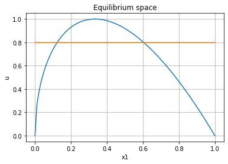

```python
b = 0.2
c = 2.6

x1 = np.array([i for i in np.linspace(0, 1, 100)])

def u(x1):
    return ( x1, c * (1 - x1) * np.sqrt(x1) )

uvec = [u(xx)[1] for xx in x1]

u_star = 0.8

plt.clf
plt.plot( x1, uvec )
plt.plot( [0.0, 1.0], [u_star, u_star] )
plt.xlabel('x1')
plt.ylabel('u')
plt.title('Equilibrium space')
plt.grid()
plt.show()
```

$u^* = 0.8 \quad \Rightarrow \quad x_1^* = 0.12 \quad$ and $\quad 0.6 \quad$ (As accurate as our eyes can see)

```python
# We set
x1_0 = 0.1 # [0, 1]

# Investigation is limited to this initial state
# x(0) = [x1(0), 0, np.sqrt(x1(0))]

# This is the ODE function that should be evaluated
# Can be done in more or less sophisticated ways but this is fine.
def f(_, x):
    dot1 = x[1]
    dot2 = -x[0] - b * x[1] + x[2] * x[2]
    dot3 = -c * (1 - x[0]) * x[2] + u_star
    return [ dot1, dot2, dot3 ]
```

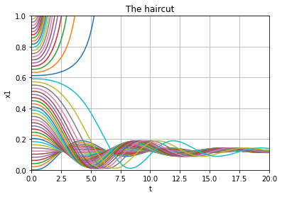

```python
# ODE sim
# Simulate for different x1(0) to investigate the ROA according to the exercise
for x1_0 in np.linspace(0, 1, 50):
    x0 = [ x1_0, 0, np.sqrt(x1_0) ]
    tspan = (0, 20)
    teval = np.linspace(tspan[0], tspan[1], 1000)
    sol = solve_ivp(f, tspan, x0, t_eval=teval)
    t = sol.t
    x = sol.y[0]
    plt.plot(t, x)
    plt.xlabel('t')
    plt.ylabel('x1')

plt.axis([0, 20, 0, 1])
plt.title('The haircut')
plt.grid()
plt.show()
```

Turn your head sideways and you will see that it looks like a haircut.

This should give some hints about the ROA and that $x_1^* = 0.12$ is stable eq. $x_1^* = 0.6$ is unstable eq. RTFM before answering...

# Exercise 2. Linear control. [3p]¶

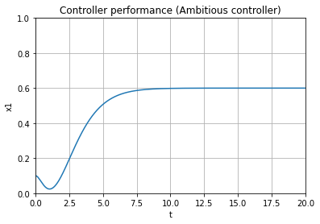

```python
# Want
x1_star = 0.6

# and
# x2_star = 0 # <-- is overkill, but we might need to show that we haven't forgot x2

# which implies that
x3_star = np.sqrt( x1_star )

# New constants
b2 = b
b3 = 2 * x3_star
c1 = c * x3_star
c3 = c * (x1_star - 1)
c13 = c

# Space space of the linearized system :
A = np.array([[0, 1, 0], [0, -b2, b3], [(c1), 0, (c3)]]) # TODO: Derive this shit
B = np.array([[0], [0], [1]])
C = np.array([1, 0, 0])
D = 0

# If we want to toy around with the linearized system we can do :
# sys = ctl.ss(A, B, C, D)
# But we ain't, because it doesn't tickle the brain in a stimulating way.

# Standard, non-fancy pole placement for state feedback controller :
# Choose poles
P = np.array([-1.2, (-1 + 0.1j), (-1 - 0.1j)]) # <-- Took the first poles that came to my brain
                                               #     But three states in the space space, calls for three poles.

# Matrix K designed
K = ctl.place(A, B, P)

# such that
# A' = (A - BK)
def linearized_transformed_f(_, y):
    dot = np.dot((A - np.dot(B,K)), y)
    return dot
# Has poles as in P

# Simulating the system under state feedback control
# with initial value
x1_0 = 0.1
# like before.

y0 = [ (x1_0-x1_star), 0, (np.sqrt(x1_0) - np.sqrt(x1_star)) ]
tspan = (0, 20)
teval = np.linspace(tspan[0], tspan[1], 1000)
sol = solve_ivp(linearized_transformed_f, tspan, y0, t_eval=teval)
t = sol.t
y = sol.y[0]
plt.plot(t, (y+x1_star))
plt.xlabel('t')
plt.ylabel('x1')
plt.grid()

plt.axis([0, 20, 0, 1])
plt.title('Controller performance (Ambitious controller)')
plt.show()
```

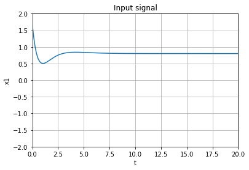

```python
# Also interested in knowing u because |u(t)| < 2.0
v_vec = -K[0][-1] * sol.y[2]
plt.plot(t, (v_vec + u_star))
plt.xlabel('t')
plt.ylabel('x1')
plt.grid()

plt.axis([0, 20, -2, 2])
plt.title('Input signal')
plt.show()
```

1. Simulate the system under feedback control. Vary the initial condition as in Exercise 1.3. Comment on the performance and the ROA.

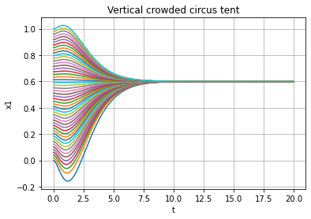

```python
# Investigation of the region of attraction with this controller

plt.clf()
for x1_0 in np.linspace(0, 1, 50):
    y0 = [ (x1_0-x1_star), 0, (np.sqrt(x1_0) - np.sqrt(x1_star)) ]
    tspan = (0, 20)
    teval = np.linspace(tspan[0], tspan[1], 1000)
    sol = solve_ivp(linearized_transformed_f, tspan, y0, t_eval=teval)
    t = sol.t
    y = sol.y[0]
    plt.plot(t, y+x1_star)
    plt.xlabel('t')
    plt.ylabel('x1')


# plt.axis([0, 20, 0, 1])
plt.grid()
plt.title('Vertical crowded circus tent')
plt.show()
```

Looks like a vertical crowded circus tent which is bad because it excludes some of the initial values from the ROA because it cannot operate outside of its domain. A problem here is that $x_1$ operates outside of its domain for some initial values.

# Exercise 3. State feedback linearization [4p]

```python
A = np.array([[0, 1, 0], [-1, -b2, 1], [0, 0, 0]])
B = np.array([[0], [0], [1]])

# These functions are only for ploting v
# Otherwise, they are in some sense obsolete because they are not included in the closed loop dynamics.
def gama(y):
    return (b3 + 2 * y[2])

def pitchfork(y):
    return ((b3 + 2 * y[2]) * (c1 * y[0] + c3 * y[2] + c13 * y[0] * y[2]))
```

Choose imput signal $v = \frac{1}{\gamma(y)}(-\psi(y) + u) = \frac{1}{\gamma(y)}(-\psi(y) + \textbf{KT}(y))$

so

$\dot{z} = \textbf{A}z + \textbf{B}(\psi(y) + \frac{\gamma(y)}{\gamma(y)}(-\psi(y) + \textbf{K}\underbrace{\textbf{T}(y)}_z) = (\textbf{A} - \textbf{BK})z$

In other words: Fight nonlinearities with magic more nonlinearity! This results in no nonlinearities in the closed loop dynamics.

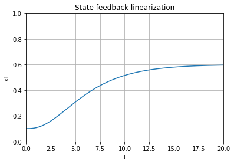

```python
# Doing the pole placement thing again, but with the

# Choose poles
P = np.array([-0.3, (-0.6 + 0.1j), (-0.6 - 0.1j)]).T

# Matrix K
K = ctl.place(A, B, P)

def state_feedbak_linearization(_, z):
    return ( np.dot((A - np.dot(B, K)), z) )

# Simulating the system under linear state feedback control

x1_0 = 0.1
y0 = [ (x1_0-x1_star), 0, (np.sqrt(x1_0) - np.sqrt(x1_star)) ]
z0 = [ y0[0], y0[1], (b3 * y0[2] + y0[2] * y0[2])]
tspan = (0, 20)
teval = np.linspace(tspan[0], tspan[1], 1000)
sol = solve_ivp(state_feedbak_linearization, tspan, z0, t_eval=teval)
t = sol.t
z = sol.y[0]
plt.plot(t, (z+x1_star))
plt.xlabel('t')
plt.ylabel('x1')
plt.grid()

plt.axis([0, 20, 0, 1])
plt.title('State feedback linearization')
plt.show()
```

After ocular inspection, we can conclude that there is no undershoot or overshoot with this controller. Not really a surprise since this is the last exercise. Would not make sense to use a more sophisticated controller to worsen the perfomance.

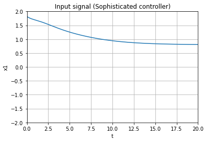

```python
# Also interested in knowing u because |u(t)| < 2.0

# Keep tongue in (own) mouth!
v_vec = ( 1 / gama(sol.y) ) * ( -pitchfork(sol.y) - K[0][-1] * sol.y)
plt.plot(t, (v_vec[2] + u_star))
plt.xlabel('t')
plt.ylabel('x1')
plt.grid()

plt.axis([0, 20, -2, 2])
plt.title('Input signal (Sophisticated controller)')
plt.show()
```

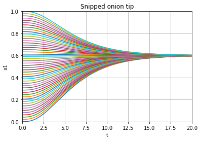

```python
# Same song and dance for this controller :

for x1_0 in np.linspace(0, 1, 50):
    x0 = [ x1_0, 0, np.sqrt(x1_0) ]
    y0 = [ (x1_0-x1_star), 0, (np.sqrt(x1_0) - np.sqrt(x1_star)) ]
    z0 = [ y0[0], y0[1], (b3 * y0[2] + y0[2] * y0[2])]
    tspan = (0, 20)
    teval = np.linspace(tspan[0], tspan[1], 1000)
    sol = solve_ivp(state_feedbak_linearization, tspan, z0, t_eval=teval)
    t = sol.t
    z = sol.y[0]
    plt.plot(t, z+x1_star)
    plt.xlabel('t')
    plt.ylabel('x1')
    plt.grid()

plt.axis([0, 20, 0, 1])
plt.title('Snipped onion tip')
plt.grid()
plt.show()
```

### Looks like the tip of an onion. Now, the ROA for $x_1$ is the whole domain but it operates only within its domain.

### I believe that we managed to duck errors this time. If you have tears running down your cheeks, you can wipe them off before submitting. Well done!